[figure not shown]

Dirección de Epidemiología

# Vigilancia intento de suicidio

Autor:

Dirección de epidemiología

Fecha:

October 31, 2024

# Vigilancia intento de suicidio

Desde la declaración de la pandemia en 2020, la Organización Mundial de la Salud (OMS) advirtió sobre los efectos en la salud mental de las personas, específicamente sobre un aumento de los padecimientos psicosociales en general y de los suicidios en particular. Un informe publicado por la OMS (2022) afirma que cada año hay 703000 defunciones por suicidio, siendo una de las principales causas de muerte. Esta situación representa un problema de salud pública creciente y prioritario tanto a nivel mundial como regional.  
En Argentina, según las estadísticas vitales de la Dirección Estadísticas e Información en Salud (DEIS), en el año 2022 hubo 3221 defunciones por suicidios (incluyendo secuelas). La Ley Nacional de Prevención del Suicidio Nº 27130 (reglamentada en 2021) declara de interés en todo el país la atención biopsicosocial, la investigación científica y epidemiológica, la capacitación profesional en la detección y atención de las personas en riesgo de suicidio y la asistencia a las familias de víctimas del suicidio. A su vez, promueve la creación de un sistema de registro único con información estadística de los intentos de suicidios, los suicidios consumados, las causas de los decesos, edad, sexo, frecuencia mensual, modalidad utilizada y todo otro dato de interés que tengan como objetivo el mejoramiento de la información estadística. A su vez, reglamenta que *“los casos de suicidio y las causas de los decesos, deben notificarse obligatoriamente a la autoridad sanitaria más próxima”.*

Descargar PDF

## Incorporación del intento de suicidio al sistema nacional de vigilancia

El objetivo de la vigilancia es caracterizar este evento de salud, estimando su magnitud y procurando identificar las poblaciones o grupos en riesgo para el fortalecimiento de la prevención y posvención (Ministerio de Salud de la Nación, 2022)

La definición epidemiológica del intento de suicidio, disponible en el Manual de Normas y Procedimientos (Ministerio de Salud de la Nación, 2021) es *“todo comportamiento para el que existe evidencia, implícita o explícita, de intencionalidad de provocarse la muerte”.* Es importante destacar que se trata de una definición epidemiológica, a los fines de los objetivos de la estrategia de vigilancia que excluye tanto a la ideación suicida como a la violencia autoinfligida sin intención suicida.

Siguiendo estos lineamientos, el intento de suicidio se clasifica:

- Sin resultado mortal: todo comportamiento con resultado no mortal para el que existe evidencia, implícita o explícita, de intencionalidad de provocarse la muerte.
- Con resultado mortal: todo comportamiento con resultado mortal para el que existe evidencia, implícita o explícita, de intencionalidad de provocarse la muerte.

## Metodología

```r
library(readxl)
library(tidyverse)
library(ggplot2)
library(dplyr)
```

```r
base <- read_excel("base.xlsx")
```

## Resultados

A continuación se presentan los resultados del análisis realizado. Desde el inicio de la vigilancia del intento de suicidio se han registrado hasta la SE41/2024 un total de 428 notificaciones a nivel provincial. En cuanto a su distribución por sexo, 61% (n=259) corresponde al sexo femenino.

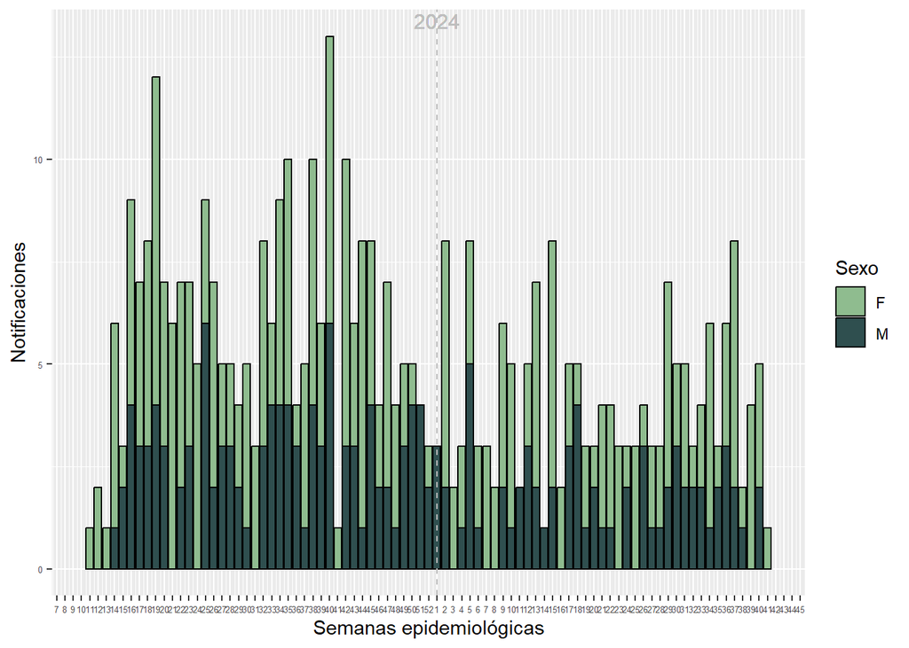

```r
base <- base %>%
  mutate(SEPI_CONTINUA = ifelse(ANIO_EPI_SINTOMA == 2023, SEPI_SINTOMA, SEPI_SINTOMA + 52))
max_count <- max(table(base$SEPI_CONTINUA))

base %>%
ggplot(aes(x = SEPI_CONTINUA, fill = SEXO)) +
  geom_bar(aes(y = ..count..), color = "black") +  # El color de borde lo puse negro
  scale_fill_manual(values = c("#8FBC8F", "#2F4F4F")) +
  scale_x_continuous(breaks = seq(1, 104, by = 1),  # 1-52 para 2023 y 53-104 para 2024
                     labels = c(as.character(1:52), as.character(1:52))) +
  labs(x = "Semanas epidemiológicas",
       y = "Notificaciones",
       fill = "Sexo")+
  theme(axis.text.x = element_text(size = 5),
        axis.text.y = element_text(size = 5),
        legend.position = "right") +
  geom_vline(xintercept = 53, linetype = "dashed", color = "grey") +  # Línea vertical en Semana 1 de 2024
  geom_text(aes(x = 53, y = max_count, label = "2024"),
            vjust = -0.5, color = "grey", size = 4)+
  guides(fill = guide_legend(override.aes = list(label = c("Femenino", "Masculino"))))
```

[output not shown]